# Asymptotics

## Definition

**Asymptotics** is the behaviour of statistics as the sample size goes to infinity.

## Law of Large Numbers (LLN)

The averages of IID samples converge to the population means they are estimating.

Example, generating random normals showing the mean as $n$ increases.

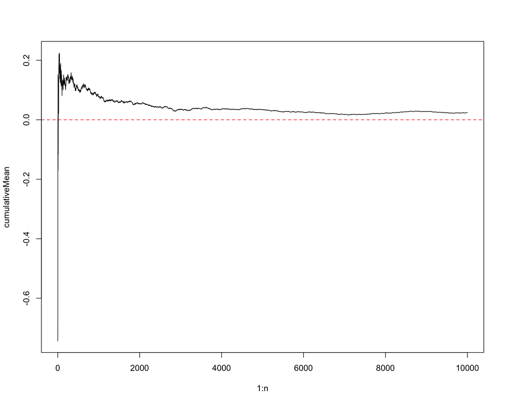

```r
n <- 10000

cumulativeMean <- cumsum(rnorm(n))/(1:n)

plot(1:n, cumulativeMean, type='l' )
abline(h=0, lty=2, col='red')
```

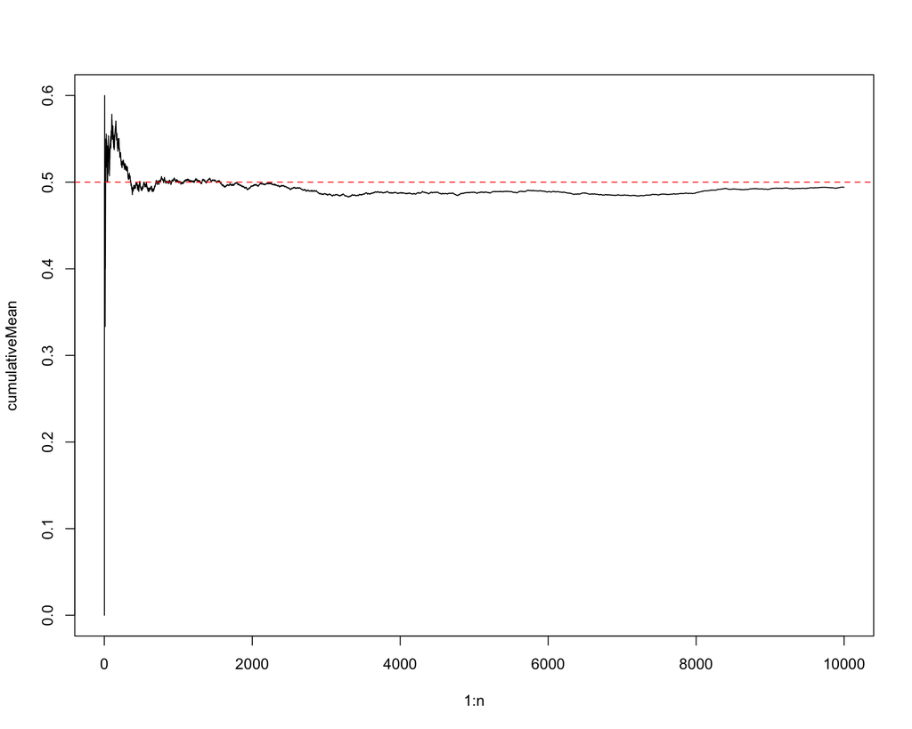

```r
n <- 10000

cumulativeMean <- cumsum(sample(0:1, n, replace=TRUE)) / (1:n)

plot(1:n, cumulativeMean, type='l' )
abline(h=0.5, lty=2, col='red')
```

- An estimator is **consistent** if it converges to what you want it to estimate
- The LLN says that the sample mean of IID samples is consistent for the population mean

## Central Limit Theorem (CLT)

**CLT** states that the distribution of averages of **IID** variables becomes that of a standard normal as the sample size increases.

## Confidence Intervals

Sample mean $\bar{X}$  
Population mean $\mu$  
Standard deviation sd $\sigma$

95% interval for the population mean, $\mu$, is $\bar{X} \pm 2\sigma / \sqrt{n}$

### Father / Son data

```r
data(father.son)

x <- father.son$sheight
n <- length(x)
meanX <- mean(x)

confidenceInterval = (meanX + c(-1,1) * qnorm(0.975) * sd(x)/sqrt(n))
```

confidence interval in inches 68.5, 68.9  
confidence interval in feet 5.71, 5.74

### Coin flips

- $X_i$ is $0$ or $1$ with success probability $p$ then $\sigma^2 = p(1-p)$

### Example using sample proportions

- For 95% intervals $\hat{p} \pm \dfrac{1}{\sqrt{n}}$ is a quick confidence interval (CI) estimate for $p$

Out of a random sample of 100 likely voters, 56 intend to vote for you. Can you relax?

Estimate:

$$\hat{p} \pm \dfrac{1}{\sqrt{n}} = \hat{p} \pm \dfrac{1} {\sqrt{100}} = \hat{p} \pm \dfrac{1} {10} = \hat{p} \pm 0.1$$

$$0.56 \pm 0.1 = \{0.46, 0.66\}$$

So, no, cannot relax according to estimate.

- $\hat{p}$ sample probability
- $z$ is the $1 - \frac{1}{2}\sigma$ quantile of a standard normal distribution

$$\hat{p} \pm z\sqrt{\dfrac{p(1-p)}{n}}$$

#### Using std error formula

```r
p <- 0.56
n <- 100

p + c(1,-1) * qnorm(0.975) * sqrt(p * (1 - p)/n)
```

```
## [1] 0.6572901 0.4627099
```

#### Using binom.test

```r
successes <- 56

btest <- binom.test(successes, n)
btest
```

```
##
##  Exact binomial test
##
## data:  successes and n
## number of successes = 56, number of trials = 100, p-value = 0.2713
## alternative hypothesis: true probability of success is not equal to 0.5
## 95 percent confidence interval:
##  0.4571875 0.6591640
## sample estimates:
## probability of success
##                   0.56
```

Rough guidelines for 95% CI based on sample size: 100 for 1 decimal place, 10k for 2, 1M for 3.

```r
  n <- c(100, 10000, 1000000, 100000000)
  CI <- round(1/sqrt(n), 4)
  kable(data.frame(n, CI))
```

| n | CI |
| --- | --- |
| 100 | 0.1000 |
| 10000 | 0.0100 |
| 1000000 | 0.0010 |
| 100000000 | 0.0001 |

### Simulation of Confidence Intervals

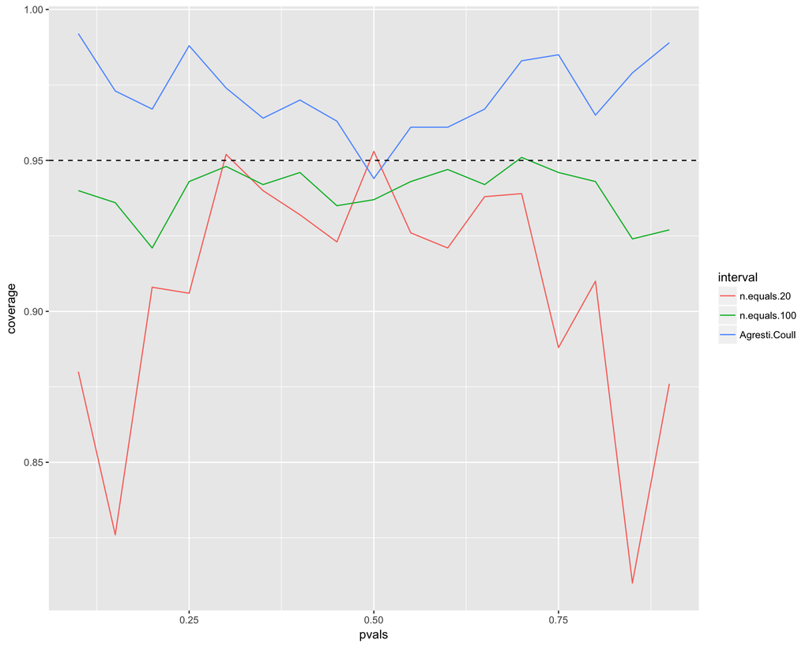

```r
n <- 20
pvals <- seq(0.1, 0.9, by = 0.05)
nosim <- 1000

n.equals.20 <- sapply(pvals, function(p) {
    phats <- rbinom(nosim, prob = p, size = n)/n
    ll <- phats - qnorm(0.975) * sqrt(phats * (1-phats)/n)
    ul <- phats + qnorm(0.975) * sqrt(phats * (1-phats)/n)
    mean(ll < p & ul > p)
  }
)

# Agresti Coull,add two successes and two failures
Agresti.Coull <- sapply(pvals, function(p) {
    phats <- (rbinom(nosim, prob = p, size = n) + 2)/(n + 4)  # +2/+4
    ll <- phats - qnorm(0.975) * sqrt(phats * (1-phats)/n)
    ul <- phats + qnorm(0.975) * sqrt(phats * (1-phats)/n)
    mean(ll < p & ul > p)
  }
)

n <- 100
n.equals.100 <- sapply(pvals, function(p) {
    phats <- rbinom(nosim, prob = p, size = n)/n
    ll <- phats - qnorm(0.975) * sqrt(phats * (1-phats)/n)
    ul <- phats + qnorm(0.975) * sqrt(phats * (1-phats)/n)
    mean(ll < p & ul > p)
  }
)

df <- data.frame(pvals, n.equals.20, n.equals.100, Agresti.Coull)
df <- melt(df, id.vars = 'pvals', value.name = 'coverage', variable.name = 'interval')

ggplot(data=df, aes(x=pvals, y=coverage, color = interval)) +
  geom_line() +
  geom_hline(yintercept = 0.95, linetype = 2)
```

## Poisson Interval

A nuclear pump failed 5 times out of 94.32 days, give 95% CI for the failure rate per day.

- $\lambda$ failure rate
- $t$ number of days
- $X \sim \text{Poisson}(\lambda t)$
- Estimate $\hat{\lambda} = X/t = 5/94.32 = 0.053011$
- $\text{Var}(\hat{\lambda}) = \lambda/t$
- $\hat{\lambda}/t$ is our variance estimate

### Using std error formula

```r
X <- 5
t <- 94.32
lambda <- X/t
CI <- lambda + c(-1,1) * qnorm(0.975) * sqrt(lambda/t)
round(CI, 3)
```

```
## [1] 0.007 0.099
```

### Using poisson.test

```r
poisson.test(X, T = t)
```

```
##
##  Exact Poisson test
##
## data:  X time base: t
## number of events = 5, time base = 94.32, p-value <
## 0.00000000000000022
## alternative hypothesis: true event rate is not equal to 1
## 95 percent confidence interval:
##  0.01721254 0.12371005
## sample estimates:
## event rate
## 0.05301103
```

### Simulating Poisson Coverage

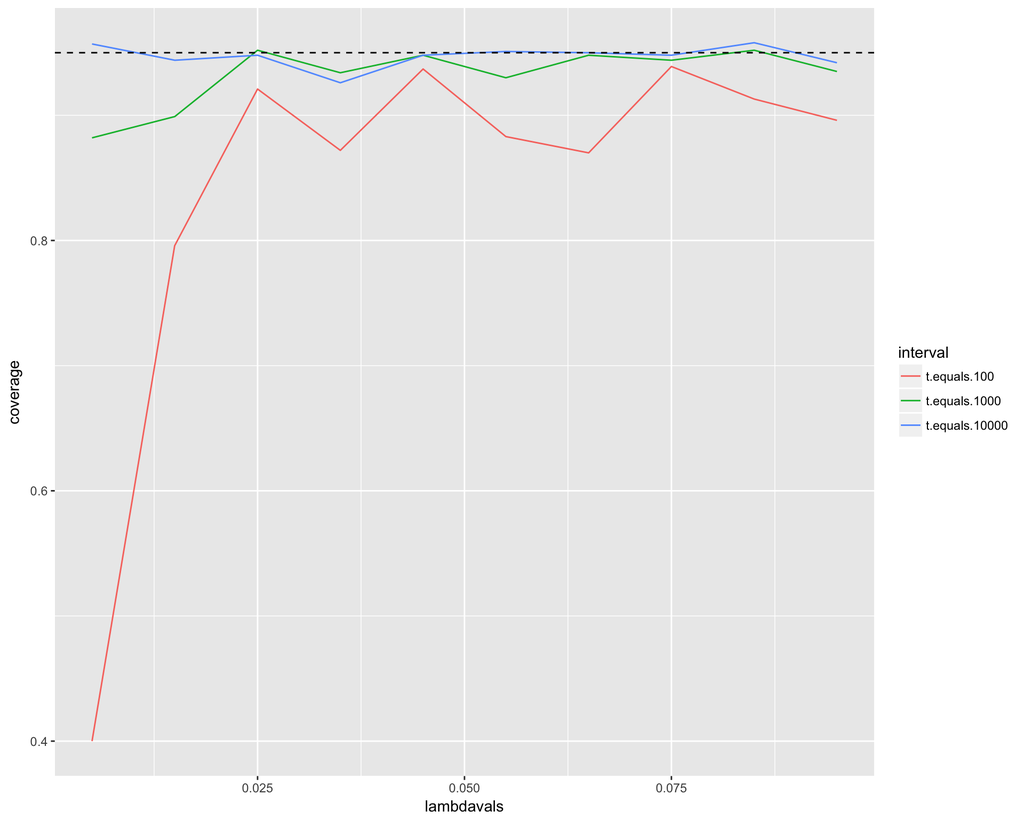

```r
lambdavals <- seq(0.005, 0.1, by = 0.01)
nosim <- 1000
t <- 100
t.equals.100 <- sapply(lambdavals, function(lambda) {
    lhats <- rpois(nosim, lambda = lambda * t)/t
    ll <- lhats - qnorm(0.975) * sqrt(lhats/t)
    ul <- lhats + qnorm(0.975) * sqrt(lhats/t)
    mean(ll < lambda & ul > lambda)
})

t <- 1000
t.equals.1000 <- sapply(lambdavals, function(lambda) {
    lhats <- rpois(nosim, lambda = lambda * t)/t
    ll <- lhats - qnorm(0.975) * sqrt(lhats/t)
    ul <- lhats + qnorm(0.975) * sqrt(lhats/t)
    mean(ll < lambda & ul > lambda)
})

t <- 10000
t.equals.10000 <- sapply(lambdavals, function(lambda) {
    lhats <- rpois(nosim, lambda = lambda * t)/t
    ll <- lhats - qnorm(0.975) * sqrt(lhats/t)
    ul <- lhats + qnorm(0.975) * sqrt(lhats/t)
    mean(ll < lambda & ul > lambda)
})

df <- data.frame(lambdavals, t.equals.100, t.equals.1000, t.equals.10000)
df <- melt(df, id.vars = 'lambdavals', value.name = 'coverage', variable.name = 'interval')

ggplot(data=df, aes(x=lambdavals, y=coverage, color = interval)) +
  geom_line() +
  geom_hline(yintercept = 0.95, linetype = 2)
```

## Summary

- LLN states that averages of iid samples converge to the population means that they are estimating
- Central Limit Theorem (CLT) states that averages are approximately normal, with distributions
  - centered at the population mean
  - with standard deviation equal to the standard error of the mean
  - CLT gives no guarantee that $n$ is large enough
- Taking the mean and adding and subtracting the relevant normal quantile times the SE yields a confidence interval for the mean
  - Adding and subtracting 2 SEs works for 95% intervals
- Confidence intervals get wider as the coverage increases
- Confidence intervals get narrower with less variability or larger sample sizes
- The Poisson and binomial case have exact intervals that don’t require the CLT
  - But a quick fix for small sample size binomial calculations is to add 2 successes and failures